# Offshore Wind Results and Analysis

Morgan Browning

28 August, 2019

# 1 Disclosure

This document functions as an all-inclusive working directory for synthesis and graphical analysis of the results from the offshore wind research of Morgan Browning, an ORISE Fellow at the U.S. Environmental Protection Agency’s Office of Research and Development. This document and its contents are not finalized nor are intended for publication.

It is annotated primarily for ease of reproducability and a general understanding of the results.

# 2 Setup

Three scripts are loaded into this markdown document to allow for analysis of the data. The setup script loads the library, creates generalized functions, and creates global variables for color scales and factors. The data script loads an excel spreadsheet with all of the results data and performs the majority of data munging. The results script creates charts, graphs, and tables. This report functions as the annotated synthesis of the data and results.

Graphs are provided with many variations to meet criteria of different publication and presentation platforms. Formats may be chosen using the `colorcalls` toggles

# 3 Scenarios

The nested parametric sensitivity analysis was built on combinations of two sets of scenarios:

1. Electric sector CO<sub>2</sub> emissions caps, as a linear decrease to a given % decrease from 2010 emissions by 2050
- Business and usual emissions represent approximately a 20% reduction in CO<sub>2</sub> emissions
2. Cost reductions of offshore wind, as a linear decrease to a given % decrease from 2010 costs by 2035, then level costs to 2050
- A 20% cost reduction is used as the base case, assuming very conservative technological advancement and little benefit of economies of scale
- Cost curves are set to resolve by 2035 as estimated based on NREL LCOE cost projections for offshore wind

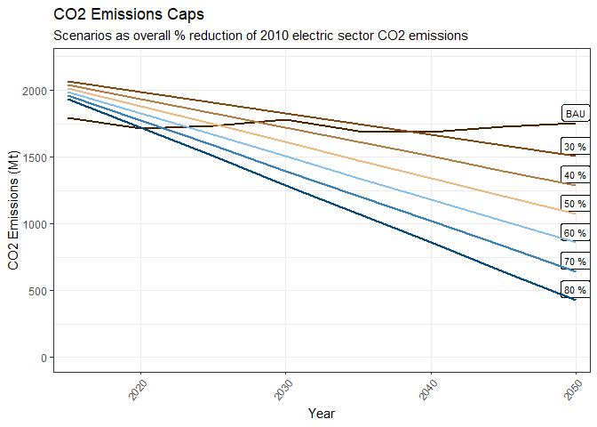

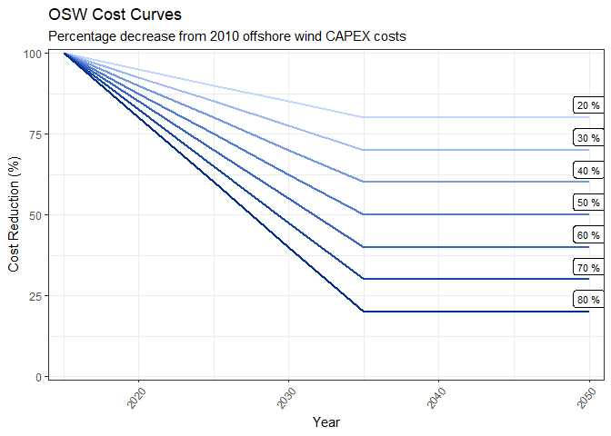

# 4 LCOE

EIA’s AEO 2019 provides the following values for the estimated levelized cost of electricity (capacity-weighted average) for new generation resources entering service in 2023 (2018 $/MWh). Offshore wind has the highest total LCOE by a large margin. The second most expensive technology is biomass. The AEO LCOE was used in the calculation of offshore wind costs for the above cost curves, but LCOE is not directly used in the model.

Estimated LCOE capacity-weighted average for new generation resources entering service in 2023 (2018 $/MWh)

| Plant Type | Capacity Factor (%) | Levelized capital cost | Levelized fixed O&M | Levelized variable O&M | Levelized transmission cost | Total system LCOE | Levelized tax credit | Total LCOE including tax credit |
| --- | --- | --- | --- | --- | --- | --- | --- | --- |
| **Dispatchable technologies** |  |  |  |  |  |  |  |  |
| Conventional CC | 87 | 8.1 | 1.5 | 32.3 | 0.9 | 42.8 | NA | 42.8 |
| Advanced CC | 87 | 7.1 | 1.4 | 30.7 | 1.0 | 40.2 | NA | 40.2 |
| Advanced CT | 30 | 17.2 | 2.7 | 54.6 | 3.0 | 77.5 | NA | 77.5 |
| Geothermal | 90 | 24.6 | 13.3 | 0.0 | 1.4 | 39.4 | -2.5 | 36.9 |
| Biomass | 83 | 37.3 | 15.7 | 37.5 | 1.5 | 92.1 | NA | 92.1 |
| **Non-dispatchable technologies** |  |  |  |  |  |  |  |  |
| Wind, onshore | 44 | 27.8 | 12.6 | 0.0 | 2.4 | 42.8 | -6.1 | 36.6 |
| Wind, offshore | 45 | 95.5 | 20.4 | 0.0 | 2.1 | 117.9 | -11.5 | 106.5 |
| Solar PV | 29 | 37.1 | 8.8 | 0.0 | 2.9 | 48.8 | -11.5 | 37.6 |
| Hydroelectric | 75 | 29.9 | 6.2 | 1.4 | 1.6 | 39.1 | NA | 39.1 |

Note:  
U.S. EIA Annual Energy Outlook 2019

# 5 Offshore Wind

As offshore wind is the primary technology being assessed in this research, we have explored many facets of offshore wind buildout. These facets are explored below, both at a regional and national cumulative level.

## 5.1 Capacity Buildout

Cumulative and new addition offshore wind capacity across all nine census regions, by cost and emissions reduction scenario.

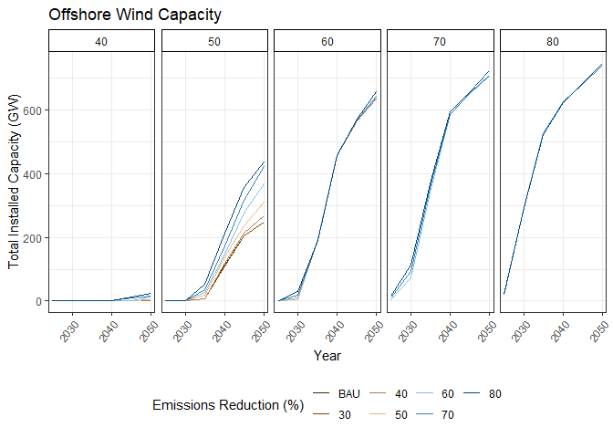

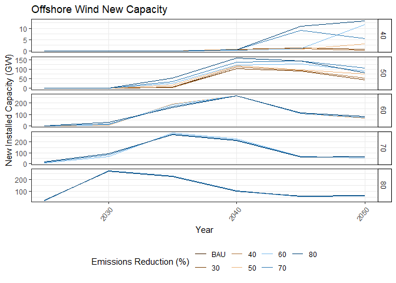

## 5.2 Total Capacity

Total offshore wind capacity across all nine census regions in 2050, by cost and emissions reduction scenario.

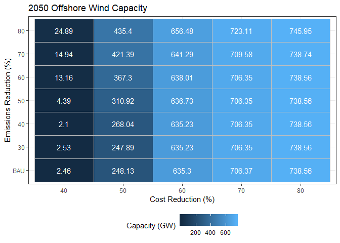

Offshore Wind Total Installed Capacity (GW): 2050

| Emissions Reduction (%) | Cost Reduction (%) 40 | Cost Reduction (%) 50 | Cost Reduction (%) 60 | Cost Reduction (%) 70 | Cost Reduction (%) 80 |
| --- | --- | --- | --- | --- | --- |
| BAU | 2.5 | 248.1 | 635.3 | 706.4 | 738.6 |
| 30 | 2.5 | 247.9 | 635.2 | 706.4 | 738.6 |
| 40 | 2.1 | 268.0 | 635.2 | 706.4 | 738.6 |
| 50 | 4.4 | 310.9 | 636.7 | 706.4 | 738.6 |
| 60 | 13.2 | 367.3 | 638.0 | 706.4 | 738.6 |
| 70 | 14.9 | 421.4 | 641.3 | 709.6 | 738.7 |
| 80 | 24.9 | 435.4 | 656.5 | 723.1 | 746.0 |

## 5.3 Output

Total offshore wind electricity output across all nine census regions, by cost and emissions reduction scenario. Results show almost identical trajectories for total capacity and output due to the non-dispatchable quality of offshore wind. All generated electricity is utilized in the modeled scenarios.

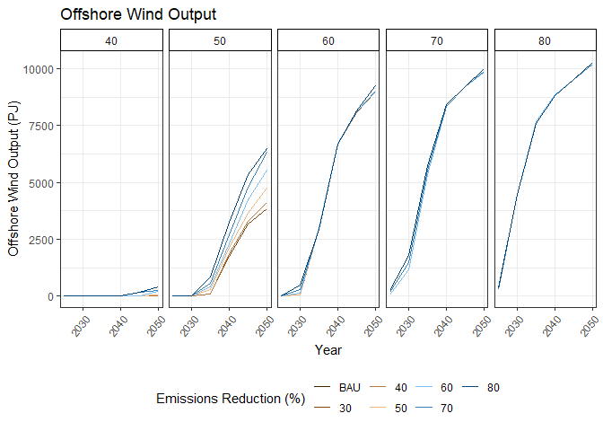

Offshore Wind Total Output (PJ): 2050

| Emissions Reduction (%) | Cost Reduction (%) 40 | Cost Reduction (%) 50 | Cost Reduction (%) 60 | Cost Reduction (%) 70 | Cost Reduction (%) 80 |
| --- | --- | --- | --- | --- | --- |
| BAU | 42.3 | 3845.4 | 8962.0 | 9848.8 | 10204.0 |
| 30 | 43.4 | 3841.7 | 8960.8 | 9848.5 | 10204.0 |
| 40 | 36.0 | 4139.4 | 8960.8 | 9848.5 | 10204.0 |
| 50 | 75.3 | 4758.1 | 8977.9 | 9848.5 | 10204.0 |
| 60 | 221.0 | 5562.3 | 8992.0 | 9848.5 | 10204.0 |
| 70 | 250.4 | 6315.4 | 9034.2 | 9880.0 | 10205.3 |
| 80 | 409.6 | 6502.2 | 9235.0 | 10008.3 | 10287.1 |

## 5.4 Regions

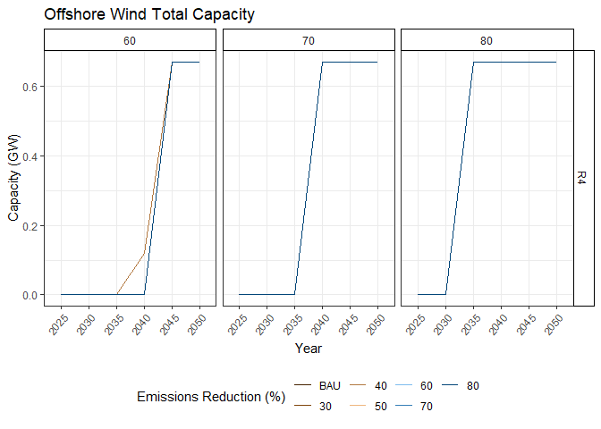

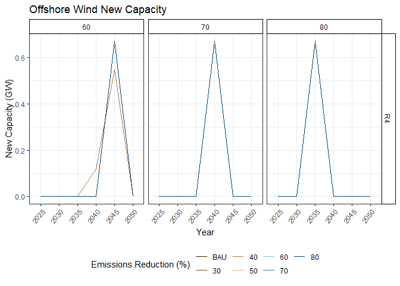

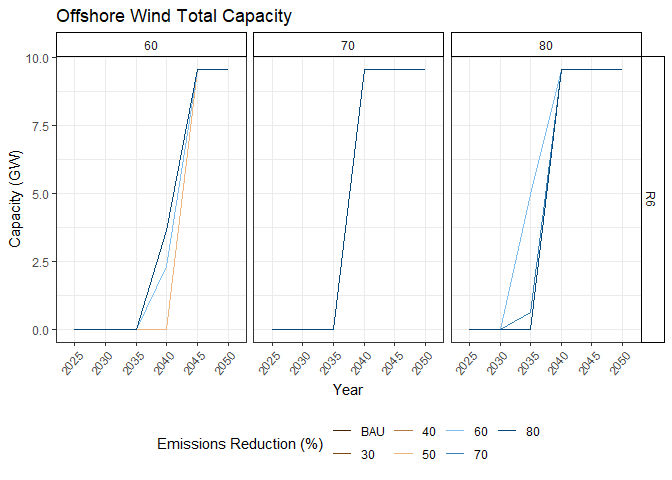

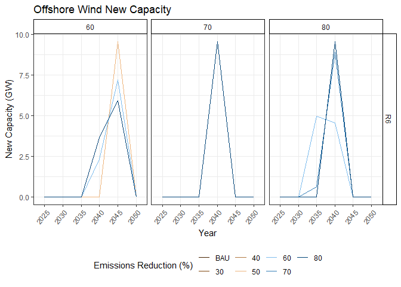

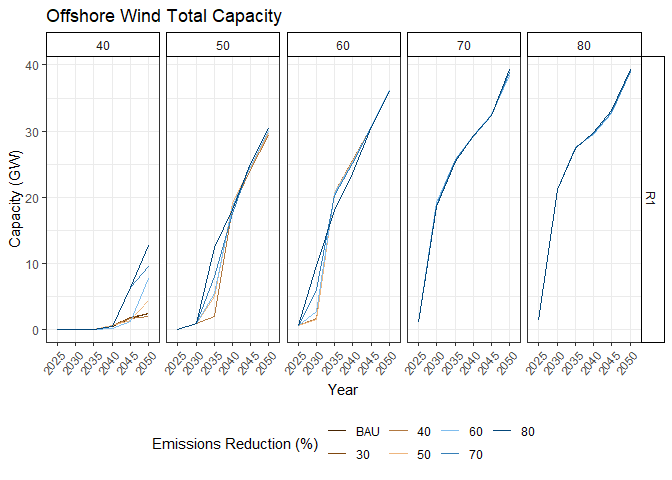

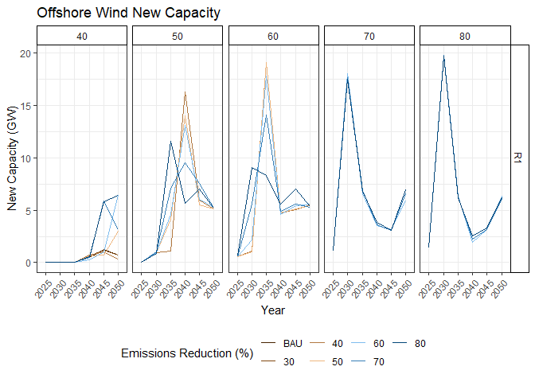

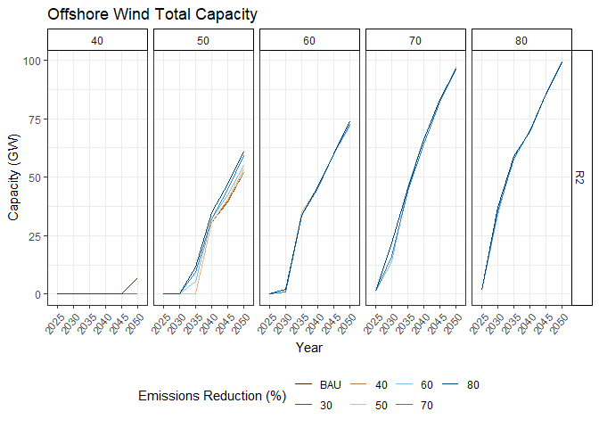

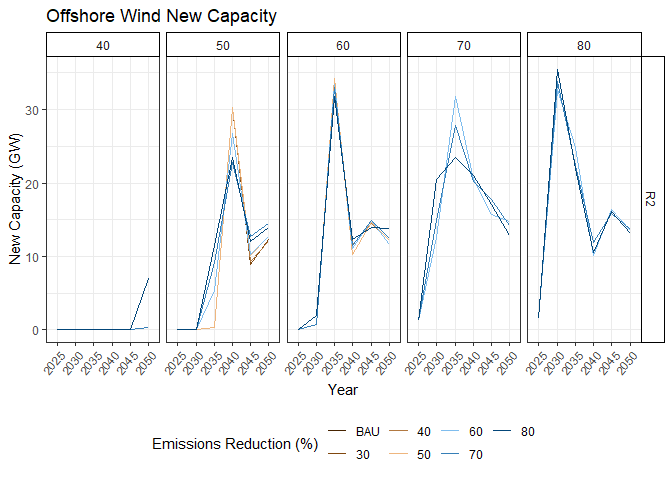

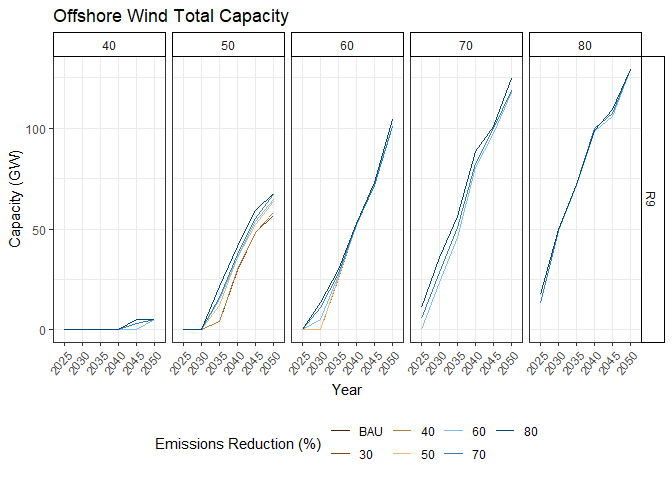

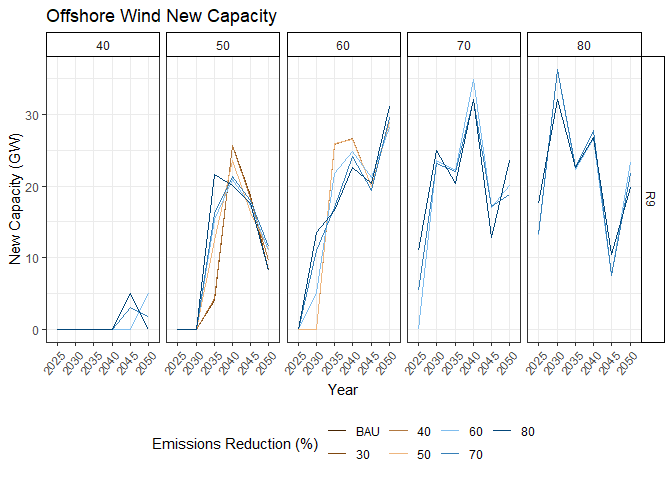

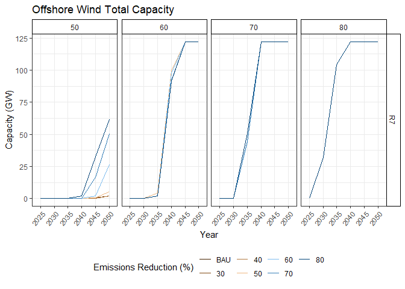

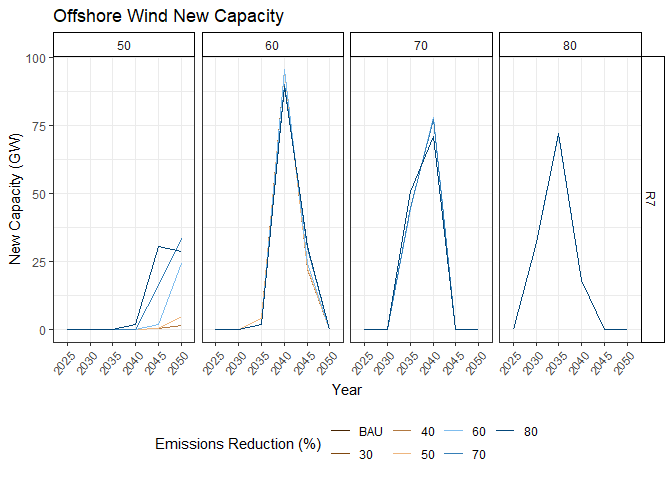

[4 more figures not shown]

Cumulative and new addition offshore wind capacity by region, emissions reduction, and cost reduction.

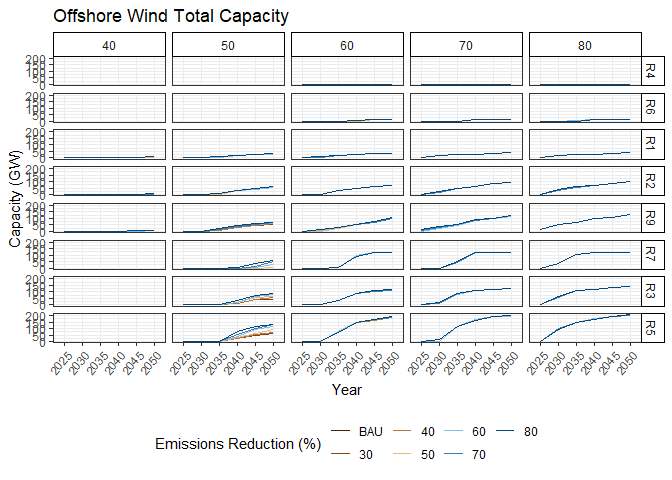

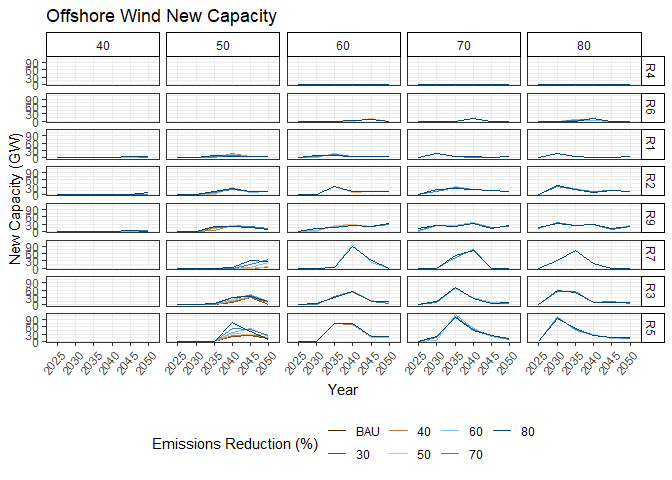

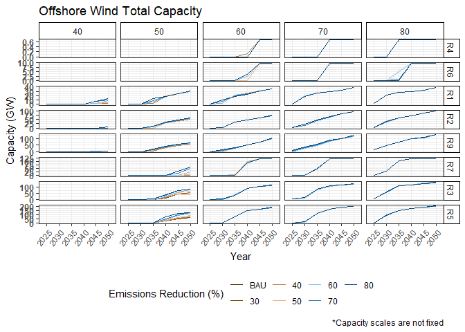

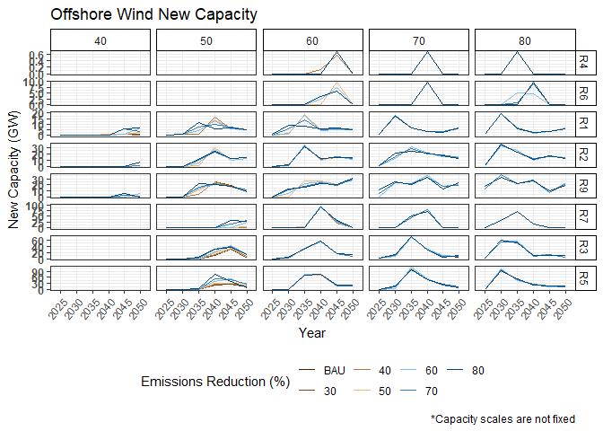

Average Installed Capacity (GW)

| Region | 2050 Total |
| --- | --- |
| R4 | 0.67000 |
| R6 | 9.56000 |
| R1 | 29.88514 |
| R2 | 73.21452 |
| R9 | 93.38871 |
| R7 | 96.97286 |
| R3 | 110.37893 |
| R5 | 169.72857 |

Average Electricity Output (PJ)

| Region | 2050 Total |
| --- | --- |
| R4 | 5.85375 |
| R6 | 68.65600 |
| R1 | 96.99500 |
| R2 | 224.66953 |
| R9 | 284.79601 |
| R3 | 326.76062 |
| R7 | 485.47903 |
| R5 | 526.62200 |

Map of average total capacity

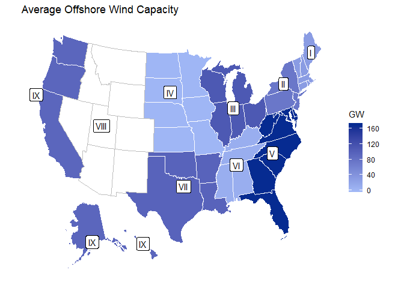

# 6 Grid Mix

## 6.1 Baseline Production

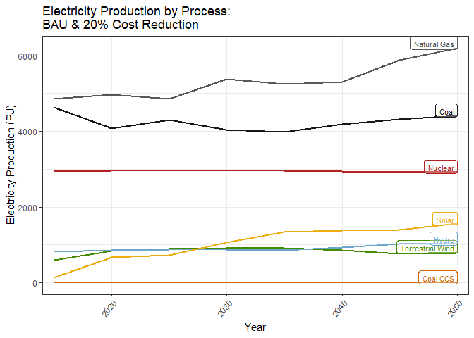

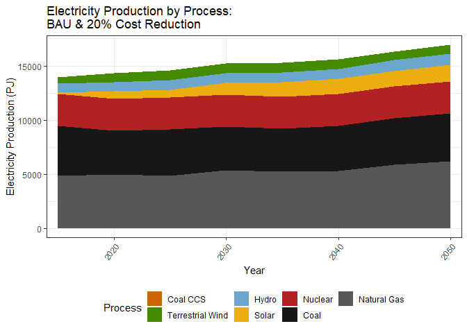

## 6.2 All Scenarios

Complete Set

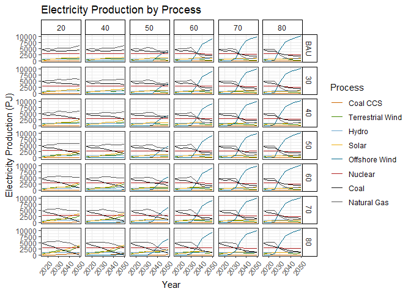

Parsed Set

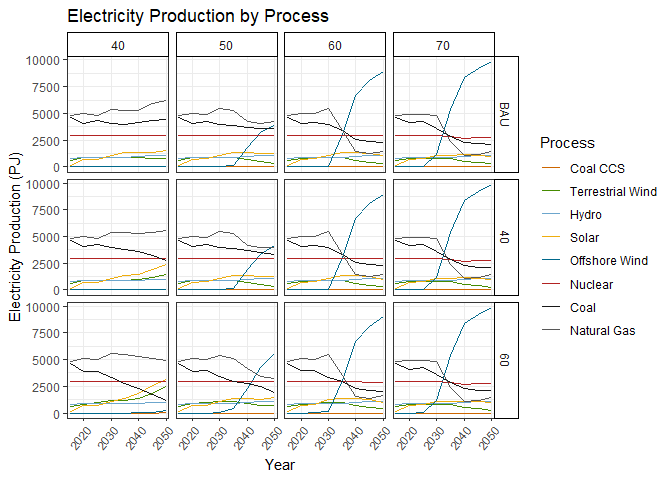

## 6.3 Emissions Cap

BAU emissions

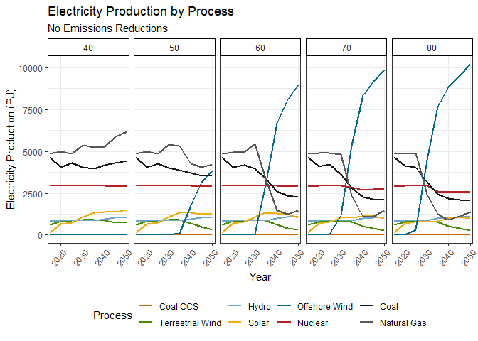

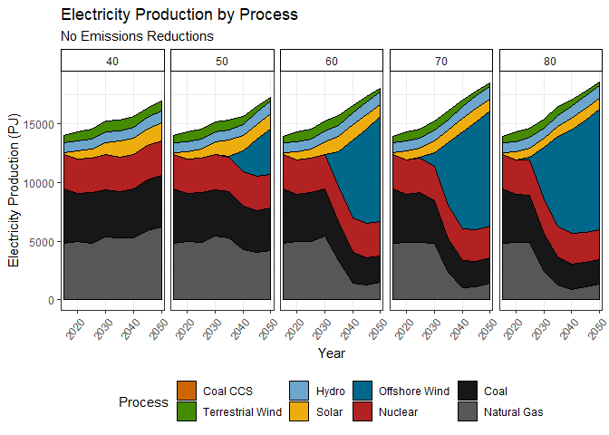

30% emissions reduction

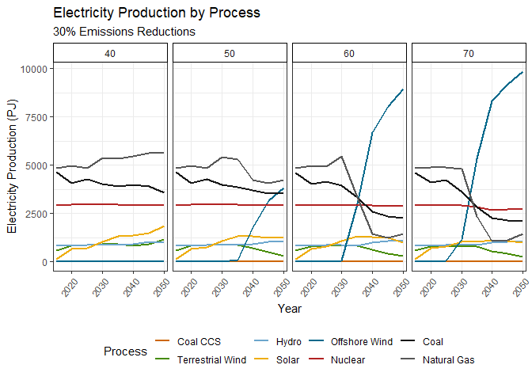

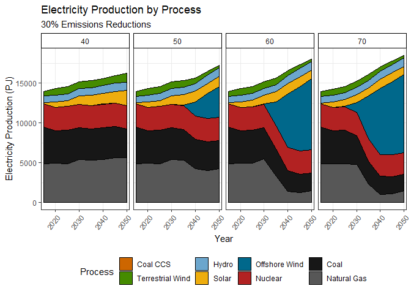

40% emissions reduction

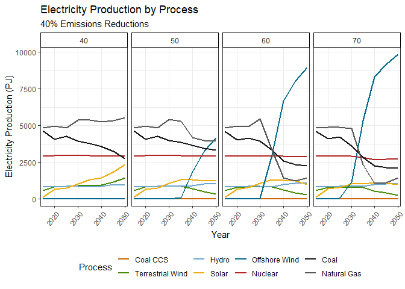

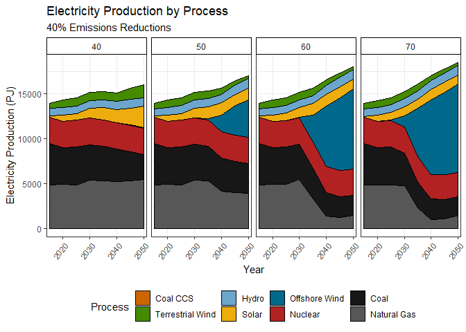

50% emissions reduction

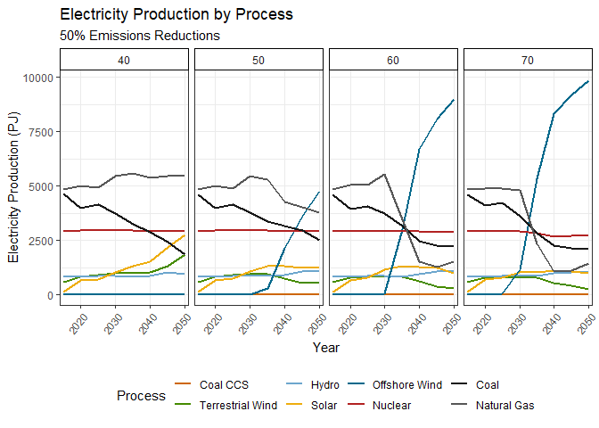

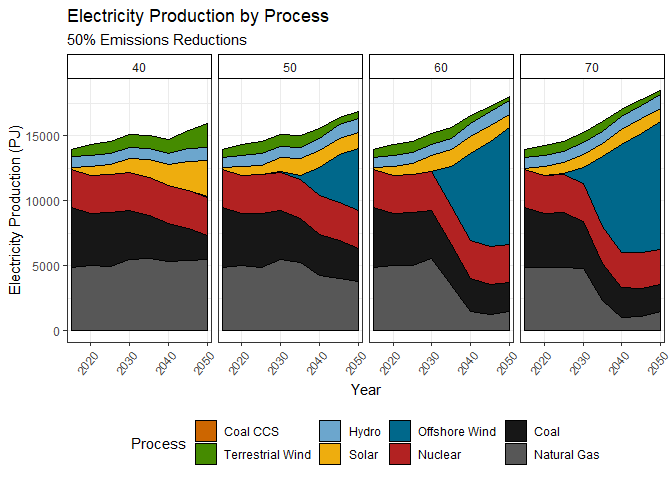

60% emissions reduction

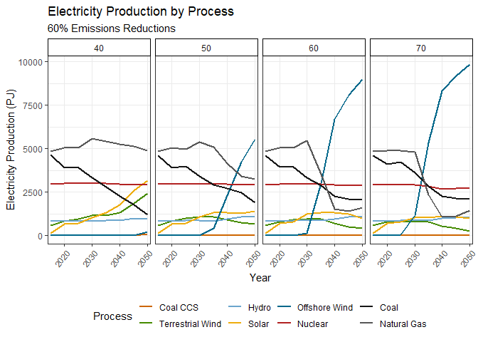

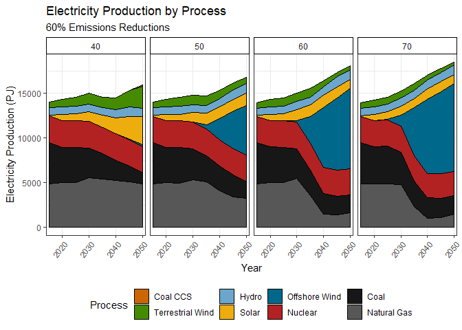

70% emissions reduction

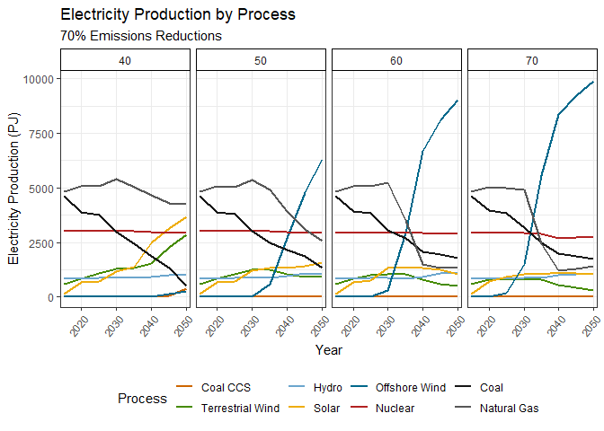

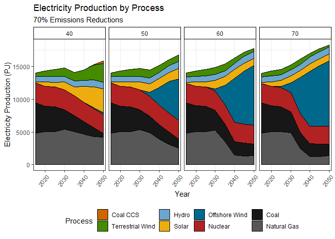

80% emissions reduction

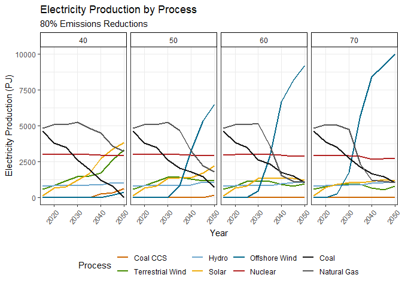

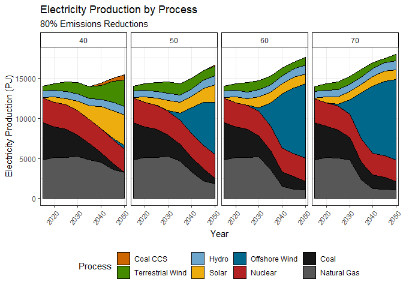

## 6.4 Cost Reductions

40% cost reduction

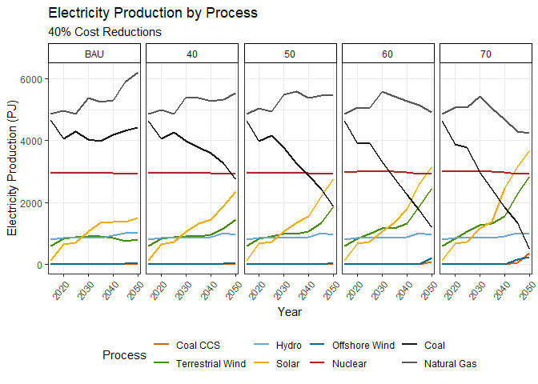

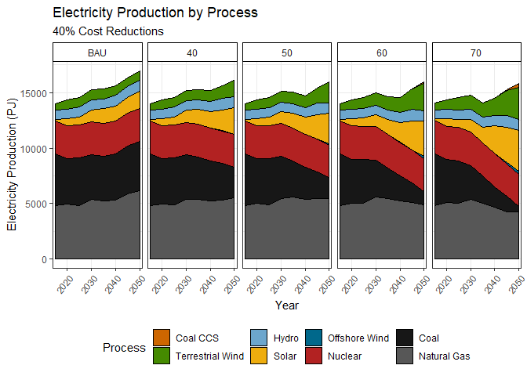

50% cost reduction

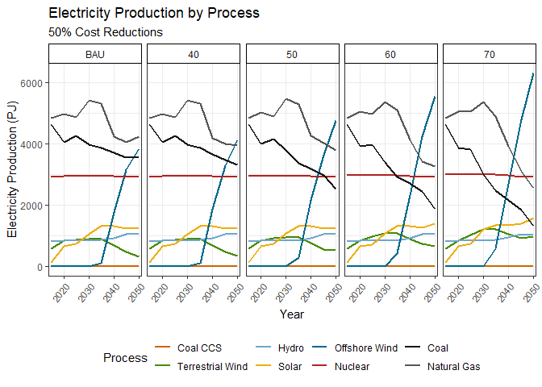

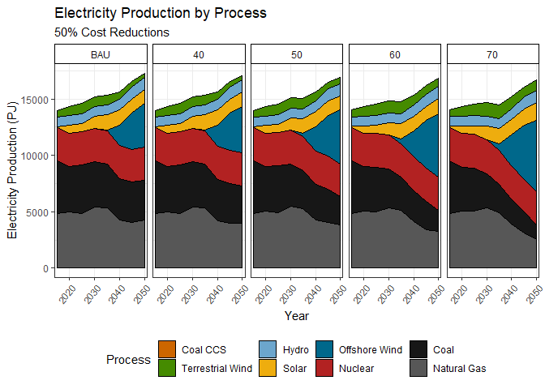

60% cost reduction

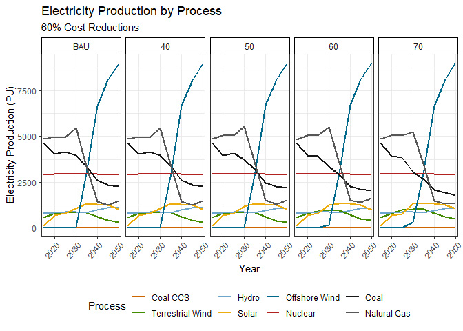

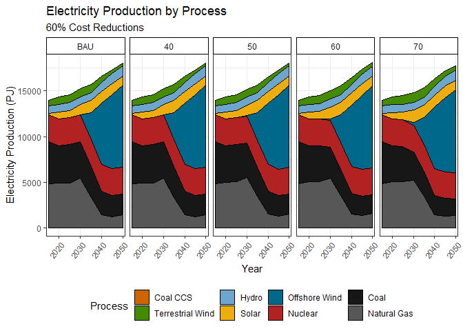

70% cost reduction

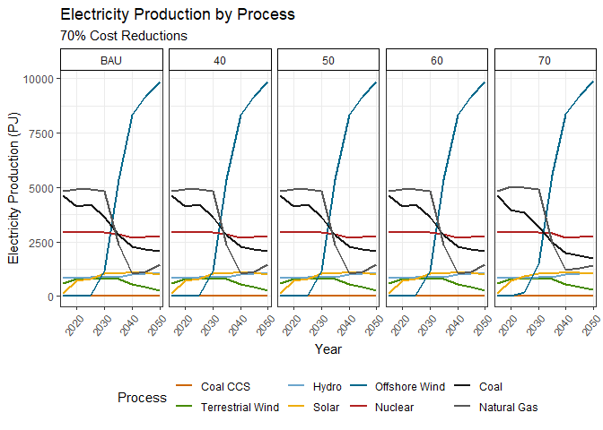

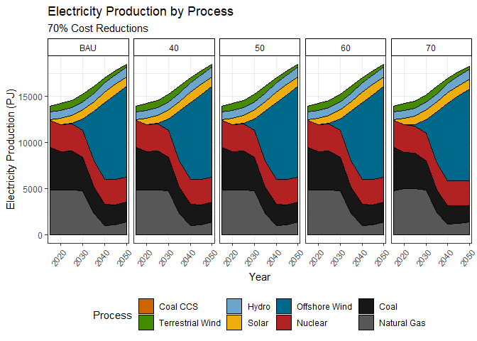

80% cost reduction

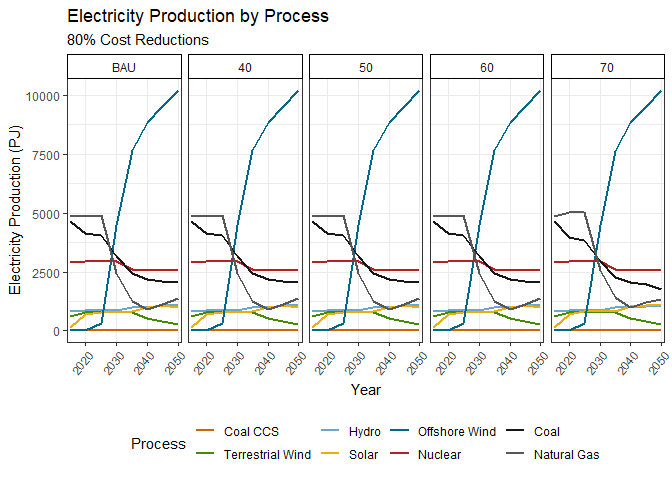

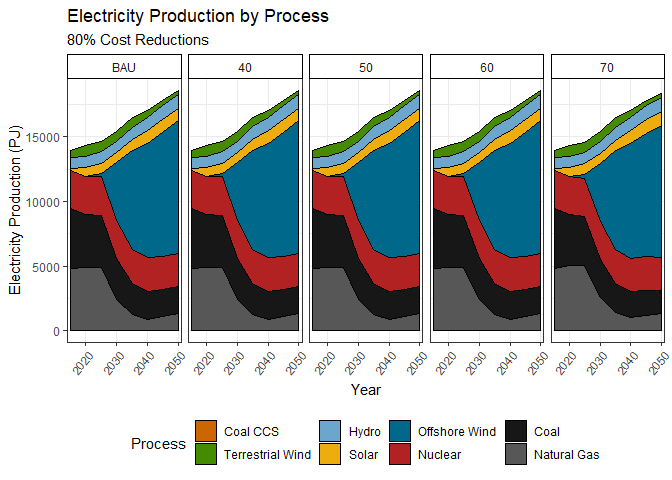